# FigureYa70mutationEvents

小丫画图出品

2019-1-20

欢迎关注“小丫画图”公众号，同名知识星球等你加入

小丫微信: epigenomics E-mail: figureya@126.com

作者：Byron

小丫编辑校验

## 需求描述

co-occurrence/mutual exclusivity分析，画出图d。

Co-occurrence/mutual exclusivity – Only mutations seen in **at least 10 patients** were kept. The **DISCOVER method** was used to determine significant mutual exclusivity and co-occurrence. A plot of the co-occurrences was generated using corrplot with the **odds ratio of the pairwise co-occurrence** used to color and scale the circle sizes.

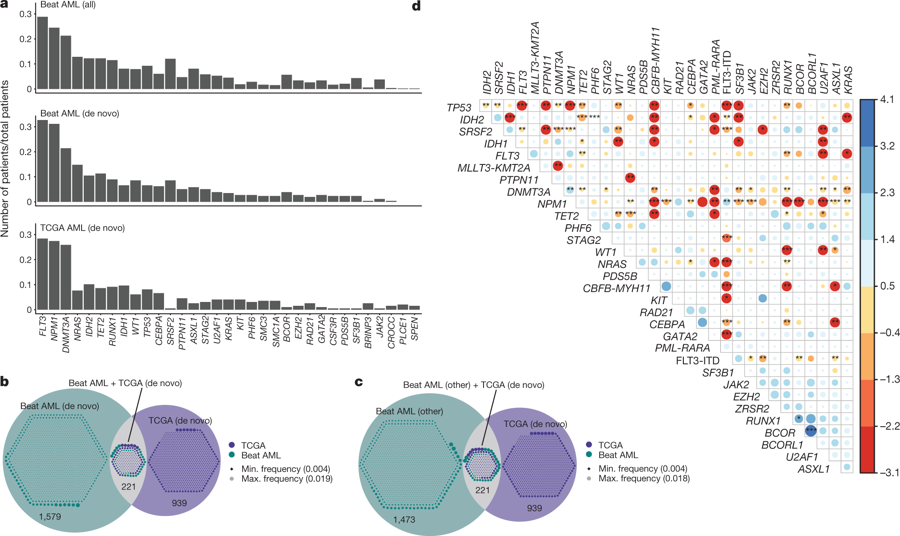

出自https://www.nature.com/articles/s41586-018-0623-z

## 应用场景

用TCGA的基因突变数据分析Co-occurrence/mutual exclusivity。

用corrplot同时展示相关性和显著性。

corrplot这个包对相关性的更多展示方式可参考http://www.sthda.com/english/wiki/visualize-correlation-matrix-using-correlogram。

## 环境设置

```r
#使用国内镜像安装包
#options("repos"= c(CRAN="https://mirrors.tuna.tsinghua.edu.cn/CRAN/"))
#options(BioC_mirror="http://mirrors.ustc.edu.cn/bioc/")
#install.packages("Cairo")
#安装discover包
#options(repos=c(getOption("repos"), "http://ccb.nki.nl/software/discover/repos/r"))
#install.packages("discover")

library(reshape2)
library(RColorBrewer)
#library(Cairo) #去掉前面的#
library(discover)
```

```r
library(readr)
library(corrplot)
library(openxlsx)

Sys.setenv(LANGUAGE = "en") #显示英文报错信息
options(stringsAsFactors = FALSE) #禁止chr转成factor
```

## 参数设置

```r
# 你感兴趣的癌症，此处以BRCA为例
target_tumor <- "BRCA"
```

## 输入文件的准备

如果你的数据已经保存为“easy_input_mutation.csv”，就可以跳过这步，直接进入“Co-occurrence/mutual exclusivity分析”。

如果只为画图，就直接进入“开始画图”。

例文没有提供基因层面的突变数据，此处以TCGA的BRCA为例，用DISCOVERY method进行co-occurrence和mutual exclusivity分析。

### 基因层面的突变数据下载

从UCSC xena的TCGA Pan-Cancer (PANCAN) (39 datasets)https://xenabrowser.net/datapages/?cohort=TCGA%20Pan-Cancer%20(PANCAN)&removeHub=https%3A%2F%2Fxena.treehouse.gi.ucsc.edu%3A443，下载两个文件：

- mc3.v0.2.8.PUBLIC.nonsilentGene.xena：somatic mutation (SNP and INDEL) - Gene level non-silent mutation。点击链接下载：https://pancanatlas.xenahubs.net/download/mc3.v0.2.8.PUBLIC.nonsilentGene.xena.gz。下载后解压缩，把mc3.v0.2.8.PUBLIC.nonsilentGene.xena文件保存到当前文件夹。里面包含TCGA所有癌症类型，用下面的代码提取你感兴趣的癌症的突变数据。
- TCGA_phenotype_denseDataOnlyDownload.tsv：phenotype - sample type and primary disease。点击链接下载：https://pancanatlas.xenahubs.net/download/TCGA_phenotype_denseDataOnlyDownload.tsv.gz
- TCGA的癌症全称和缩写的对应关系，参照GEPIA help的Differential analysis：http://gepia.cancer-pku.cn/help.html，整理成samplepair.txt文件

```r
#library(readr)
#数据量很大，读入可能需要一段时间
mutationinfo <- read_tsv(file = "mc3.v0.2.8.PUBLIC.nonsilentGene.xena")
mutationinfo[1:5,1:5]
```

```
## # A tibble: 5 x 5
##   sample `TCGA-02-0003-0… `TCGA-02-0033-0… `TCGA-02-0047-0…
##   <chr>             <dbl>            <dbl>            <dbl>
## 1 UBE2Q2                0                0                0
## 2 CHMP1B                0                0                0
## 3 PSMA2…                0                0                0
## 4 SHQ1P1                0                0                0
## 5 CPHL1P                0                0                0
## # … with 1 more variable: `TCGA-02-0055-01` <dbl>
```

```r
samplepair <- read.delim("samplepair.txt",as.is = T)
gtexpair <- samplepair[,c(1,2,5)]
gtexpair
```

```
##    TCGA                                Detail          GTEx
## 1   ACC                 adrenocortical cancer Adrenal Gland
## 2  BLCA          bladder urothelial carcinoma       Bladder
## 3  BRCA             breast invasive carcinoma        Breast
## 4  CESC        cervical & endocervical cancer  Cervix Uteri
## 5  CHOL                    cholangiocarcinoma             -
## 6  COAD                  colon adenocarcinoma         Colon
## 7  DLBC         diffuse large B-cell lymphoma         Blood
## 8  ESCA                  esophageal carcinoma     Esophagus
## 9   GBM               glioblastoma multiforme         Brain
## 10 HNSC   head & neck squamous cell carcinoma             -
## 11 KICH                    kidney chromophobe        Kidney
## 12 KIRC           kidney clear cell carcinoma        Kidney
## 13 KIRP       kidney papillary cell carcinoma        Kidney
## 14 LAML                acute myeloid leukemia   Bone Marrow
```

[output cut: 19 more lines]

```r
#以TCGA的缩写为GTEx的组织命名
gtexpair$type <- paste0(gtexpair$TCGA,"_normal_GTEx")
gtexpair$type2 <-"normal"
gtextcga <- gtexpair[,c(1,3:5)] #筛掉Detail列
colnames(gtextcga)[1:2] <- c("tissue","X_primary_site")
head(gtextcga)
```

```
##   tissue X_primary_site             type  type2
## 1    ACC  Adrenal Gland  ACC_normal_GTEx normal
## 2   BLCA        Bladder BLCA_normal_GTEx normal
## 3   BRCA         Breast BRCA_normal_GTEx normal
## 4   CESC   Cervix Uteri CESC_normal_GTEx normal
## 5   CHOL              - CHOL_normal_GTEx normal
## 6   COAD          Colon COAD_normal_GTEx normal
```

```r
#为GTEx的sample标出组织
gtexcase <- read.delim(file="GTEX_phenotype.tsv",header=T,as.is = T)
colnames(gtexcase)[1] <- "sample"
gtexcase2tcga <- merge(gtextcga,gtexcase,by="X_primary_site")
gtextable <- gtexcase2tcga[,c(5,2:4)]
head(gtextable)
```

```
##                    sample tissue            type  type2
## 1 GTEX-QMRM-0126-SM-4R1K9    ACC ACC_normal_GTEx normal
## 2 GTEX-S32W-0126-SM-4AD61    ACC ACC_normal_GTEx normal
## 3 GTEX-ZUA1-1926-SM-5E45E    ACC ACC_normal_GTEx normal
## 4 GTEX-ZY6K-0126-SM-5SIAM    ACC ACC_normal_GTEx normal
## 5 GTEX-ZYWO-0126-SM-5GZWQ    ACC ACC_normal_GTEx normal
## 6 GTEX-XQ3S-1726-SM-4BOOD    ACC ACC_normal_GTEx normal
```

```r
tissue <- gtexpair$TCGA
names(tissue) <- gtexpair$Detail

tcgacase <- read.delim(file="TCGA_phenotype_denseDataOnlyDownload.tsv",header=T,as.is = T)
tcgacase$tissue <- tissue[tcgacase$X_primary_disease]
tcgacase$type <- ifelse(tcgacase$sample_type=='Solid Tissue Normal',paste(tcgacase$tissue,"normal_TCGA",sep="_"),paste(tcgacase$tissue,"tumor_TCGA",sep="_"))
tcgacase$type2 <- ifelse(tcgacase$sample_type=='Solid Tissue Normal',"normal","tumor")
tcgatable<-tcgacase[,c(1,5:7)]
head(tcgatable)
```

```
##            sample tissue            type type2
## 1 TCGA-D3-A1QA-07   SKCM SKCM_tumor_TCGA tumor
## 2 TCGA-DE-A4MD-06   THCA THCA_tumor_TCGA tumor
## 3 TCGA-J8-A3O2-06   THCA THCA_tumor_TCGA tumor
## 4 TCGA-J8-A3YH-06   THCA THCA_tumor_TCGA tumor
## 5 TCGA-EM-A2P1-06   THCA THCA_tumor_TCGA tumor
## 6 TCGA-J8-A4HW-06   THCA THCA_tumor_TCGA tumor
```

### 提取你感兴趣的癌症的突变数据

```r
library(data.table)
target_sample <- tcgacase[tcgacase$tissue == target_tumor & tcgatable$type2 == "tumor",]

target_mutationinfo <- mutationinfo[,colnames(mutationinfo) %in% target_sample$sample]
head(target_mutationinfo)
```

[output not shown]

```r
#table(colnames(mutationinfo) %in% target_sample$sample)
target_mutationinfo$sample = mutationinfo$sample
target_mutationinfo = target_mutationinfo[complete.cases(target_mutationinfo[,"sample"]),]
target_mutationinfo = as.data.frame(target_mutationinfo)
rownames(target_mutationinfo) = target_mutationinfo$sample
target_mutationinfo = target_mutationinfo[,-length(target_mutationinfo)]
target_mutationinfo[1:5,1:5]
```

```
##         TCGA-3C-AAAU-01 TCGA-3C-AALI-01 TCGA-3C-AALJ-01 TCGA-3C-AALK-01
## UBE2Q2                0               0               0               0
## CHMP1B                0               0               0               0
## PSMA2P1               0               0               0               0
## SHQ1P1                0               0               0               0
## CPHL1P                0               0               0               0
##         TCGA-4H-AAAK-01
## UBE2Q2                0
## CHMP1B                0
## PSMA2P1               0
## SHQ1P1                0
## CPHL1P                0
```

```r
#保存到文件
#write.csv(target_mutationinfo, "easy_input_mutation.csv",quote = F)
#此处保存局部，用于查看文件格式
write.csv(target_mutationinfo[,1:5], "easy_input_mutation.csv",quote = F)
```

## Co-occurrence/mutual exclusivity分析

DESCOVERY method，用R版本的DESCOVERY计算co-occurrence和mutual exclusivity。

参考资料：https://github.com/NKI-CCB/DISCOVER

http://ccb.nki.nl/software/discover/doc/r/discover-intro.html

下面使用Discover包进行co-occurrence和mutual exclusivity分析

需要引用的文献：https://genomebiology.biomedcentral.com/articles/10.1186/s13059-016-1114-x

```r
# 输入文件：每个基因在每个sample里是否发生突变，0为未突变，1为突变。每行一个基因，每列一个sample。
#target_mutationinfo <- read.csv("easy_input_mutation.csv", row.names = 1)
#target_mutationinfo[1:5,1:5]

library(discover)
#step1 估计背景矩阵，这一步会比较花时间
events <- discover.matrix(target_mutationinfo)

#step2 选择至少在25个肿瘤样本中都有突变的基因
subset <- rowSums(target_mutationinfo) > 25

#step3 进行pairwise test，这一步用来进行mutual exclusivity的运算。
result.mutex <- pairwise.discover.test(events[subset, ],alternative=c("less"))
result.mutex
```

```
## Pairwise DISCOVER mutual exclusivity test
## alternative hypothesis: observed overlap is less than expected by chance
##
## number of pairs tested: 946
## proportion of true null hypotheses: 0.6791881
## number of significant pairs at a maximum FDR of 0.01 : 36
```

```r
print(result.mutex, fdr.threshold=0.05)
```

```
## Pairwise DISCOVER mutual exclusivity test
## alternative hypothesis: observed overlap is less than expected by chance
##
## number of pairs tested: 946
## proportion of true null hypotheses: 0.6791881
## number of significant pairs at a maximum FDR of 0.05 : 105
```

```r
result = as.data.frame(result.mutex)
write.csv(result,file = "Target_cancer_discover_less.csv")

#进行co-occurence的计算，加入参数alternative=c("greater")
result.mutex <- pairwise.discover.test(events[subset, ],alternative=c("greater"))
print(result.mutex, fdr.threshold=0.05)
```

```
## Pairwise DISCOVER co-occurrence test
## alternative hypothesis: observed overlap is greater than expected by chance
##
## number of pairs tested: 946
## proportion of true null hypotheses: 1
## number of significant pairs at a maximum FDR of 0.05 : 0
```

```r
result = as.data.frame(result.mutex)
write.csv(result,file = "Target_cancer_discover_greater.csv")
```

例文的图中有两个输入：P value和odds ratio。

Figure legend of Figure 1d.d, Co-occurrence or exclusivity of the most recurrent mutational events in the Beat AML cohort (n = 531 patients) were assessed using the DISCOVER method. The dot plot shows the odds ratio of co-occurrence (blue) or exclusivity (red) using colour-coding and circle size as well as asterisks that indicate FDR-corrected statistical significance. *P < 0.1; **P < 0.05;*** P < 0.01.

And the discription in Methods: Co-occurrence and mutual exclusivity. Only mutations seen in at least 10 patients were kept. The DISCOVER41 method was used to determine significant mutual exclusivity and co-occurrence. A plot of the co-occurrences was generated using corrplot84 with the odds ratio of the pairwise co-occurrence used to colour and scale the circle sizes.

然而DESCOVER并不输出odds ratio，原文未描述odds ratio的计算方法，联系通讯作者未得到回复。欢迎对odds ratio的计算感兴趣的小伙伴来小丫画图知识星球或微信群里讨论。

## 例文的原图复现

### 输入文件

输入数据来源：例文的Source Data Fig. 1，https://static-content.springer.com/esm/art%3A10.1038%2Fs41586-018-0623-z/MediaObjects/41586_2018_623_MOESM4_ESM.xlsx，Tab C。

```r
# 读入文件第3个sheet中的我们需要的列
library(openxlsx)
input <- read.xlsx("41586_2018_623_MOESM4_ESM.xlsx", sheet = 3, cols=c(1,2,5,6), startRow = 1)
# 保存到文件
write.csv(input, "easy_input.csv", quote = F)
```

转换成两个矩阵inputdata和input_pvalue，分别表示Odd_ratio和p值的矩阵 输入矩阵至少包含：基因对，Odd_ratio，P值

```r
input <- read.csv("easy_input.csv", row.names = 1)
head(input)
```

```
##        Gene1  Gene2    mutex_q  log_odds
## 1       BCOR  ASXL1 0.92690831  1.142672
## 2     BCORL1  ASXL1 0.96811623  1.504077
## 3     BCORL1   BCOR 0.99999731  4.100387
## 4 CBFB.MYH11  ASXL1 0.05719902 -3.097422
## 5 CBFB.MYH11   BCOR 0.13699487  0.000000
## 6 CBFB.MYH11 BCORL1 0.48829063  0.000000
```

```r
# Odd_ratio，点的颜色
input_data = input[,c(1:2,4)] #选择Gene1,Gene2,odd_Ratio列
input_data = dcast(input_data, Gene1 ~ Gene2)
rownames(input_data) = input_data$Gene1
input_data = input_data[,-1]
input_data = as.matrix(input_data)
input_data[1:5,1:5]
```

```
##                ASXL1       BCOR   BCORL1 CBFB.MYH11      CEBPA
## ASXL1             NA  1.1426723 1.504077  -3.097422 -3.0974223
## BCOR        1.142672         NA 4.100387   0.000000 -0.6485503
## BCORL1      1.504077  4.1003869       NA   0.000000  0.0000000
## CBFB.MYH11 -3.097422  0.0000000 0.000000         NA  0.0000000
## CEBPA      -3.097422 -0.6485503 0.000000   0.000000         NA
```

```r
# pvalue，点的大小和***
input_pvalue = input[,c(1:3)]
input_pvalue = dcast(input_pvalue, Gene1 ~ Gene2)
rownames(input_pvalue) = input_pvalue$Gene1
input_pvalue = input_pvalue[,-1]
input_pvalue = as.matrix(input_pvalue)
rownames(input_pvalue) = colnames(input_pvalue)
input_pvalue[1:5,1:5]
```

```
##                 ASXL1      BCOR    BCORL1 CBFB.MYH11      CEBPA
## ASXL1              NA 0.9269083 0.9681162 0.05719902 0.03209622
## BCOR       0.92690831        NA 0.9999973 0.13699487 0.28601045
## BCORL1     0.96811623 0.9999973        NA 0.48829063 0.42073642
## CBFB.MYH11 0.05719902 0.1369949 0.4882906         NA 0.12444417
## CEBPA      0.03209622 0.2860104 0.4207364 0.12444417         NA
```

### 开始画图

```r
CairoPDF("mutationplot.pdf")
corrplot(input_data, #对于一般的矩阵，必须使用is.corr = FALSE
         type = "upper", #只显示上三角
         order="hclust",
         col=brewer.pal(n=8, name="RdBu"),
         tl.col="black", #文字颜色
         tl.cex = 0.5, #文字大小
         tl.srt = 90, #文字旋转角度
         is.corr = FALSE, #非相关系数矩阵
         diag = F,  #不展示相关系数
         p.mat = input_pvalue, #p值的矩阵
         sig.level = c(.001, .05, .1), #显著水平
         insig = c("label_sig"), #显著水平以***、**、*表示
         pch.cex = 0.5, #标注的p值大小
         font = 3) #斜体
dev.off()
```

[figure not shown]